```r
choco <- read.csv("https://raw.githubusercontent.com/xdaiISU/ds202materials/master/hwlabs/data/choco.csv")
str(choco)
```

```
## 'data.frame':    2312 obs. of  13 variables:
##  $ REF                 : int  2454 2458 2454 797 797 1015 1019 1011 1019 1011 ...
##  $ Company             : chr  "5150" "5150" "5150" "A. Morin" ...
##  $ Location            : chr  "U.S.A." "U.S.A." "U.S.A." "France" ...
##  $ Date                : int  2019 2019 2019 2012 2012 2013 2013 2013 2013 2013 ...
##  $ Bean_Origin         : chr  "Madagascar" "Dominican Republic" "Tanzania" "Peru" ...
##  $ Specific_Bean_Origin: chr  "Bejofo Estate, batch 1" "Zorzal, batch 1" "Kokoa Kamili, batch 1" "Peru" ...
##  $ Cocoa_Percent       : num  76 76 76 63 70 70 63 70 70 70 ...
##  $ Ingredients         : chr  "3- B,S,C" "3- B,S,C" "3- B,S,C" "4- B,S,C,L" ...
##  $ Characteristics1    : chr  "cocoa" "cocoa" "rich cocoa" "fruity" ...
##  $ Characteristics2    : chr  "blackberry" "vegetal" "fatty" "melon" ...
##  $ Characteristics3    : chr  "full body" "savory" "bready" "roasty" ...
##  $ Characteristics4    : chr  NA NA NA NA ...
##  $ Rating              : num  3.75 3.5 3.25 3.75 3.5 4 4 3.75 3.5 3.25 ...
```

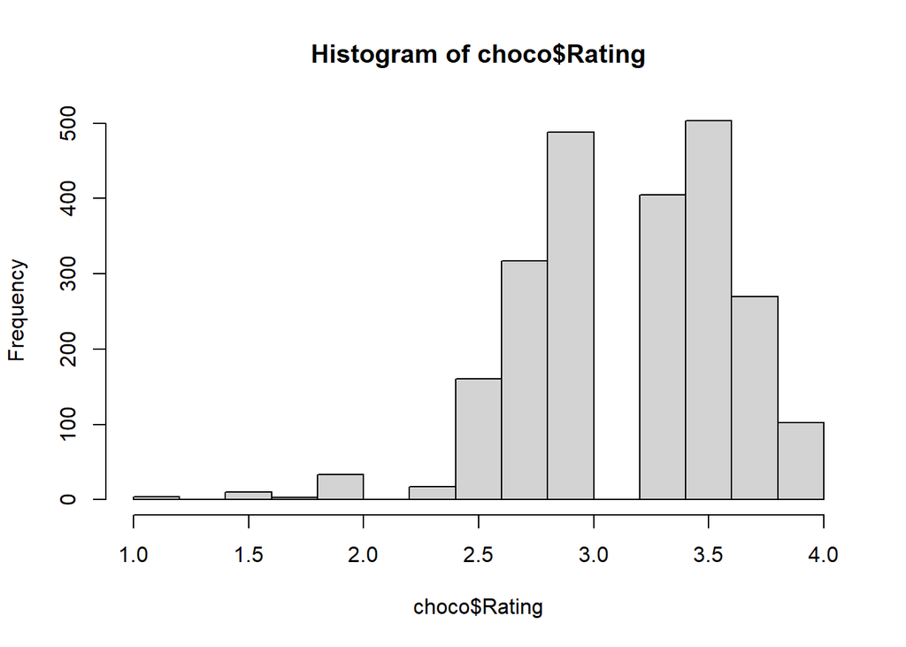

```r
hist(choco$Rating)
```

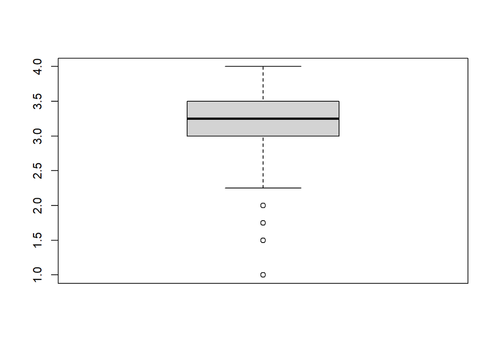

```r
boxplot(choco$Rating)
```

1. I would consider the ratings skew left. There a small number of outliers only near the bottom of the ratings.

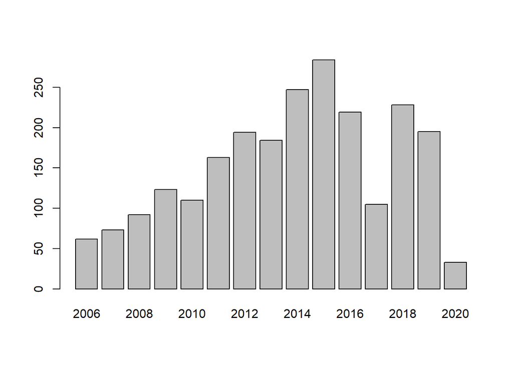

```r
barplot(table(choco$Date))
```

2. The number of ratings are greatest around 2015, but there are considerably less ratings during the first few years that ratings were given and some of the more recent years have lower review numbers than previous years

```r
summary(choco$Cocoa_Percent)
```

```
##    Min. 1st Qu.  Median    Mean 3rd Qu.    Max.
##   42.00   70.00   70.00   71.65   75.00  100.00
```

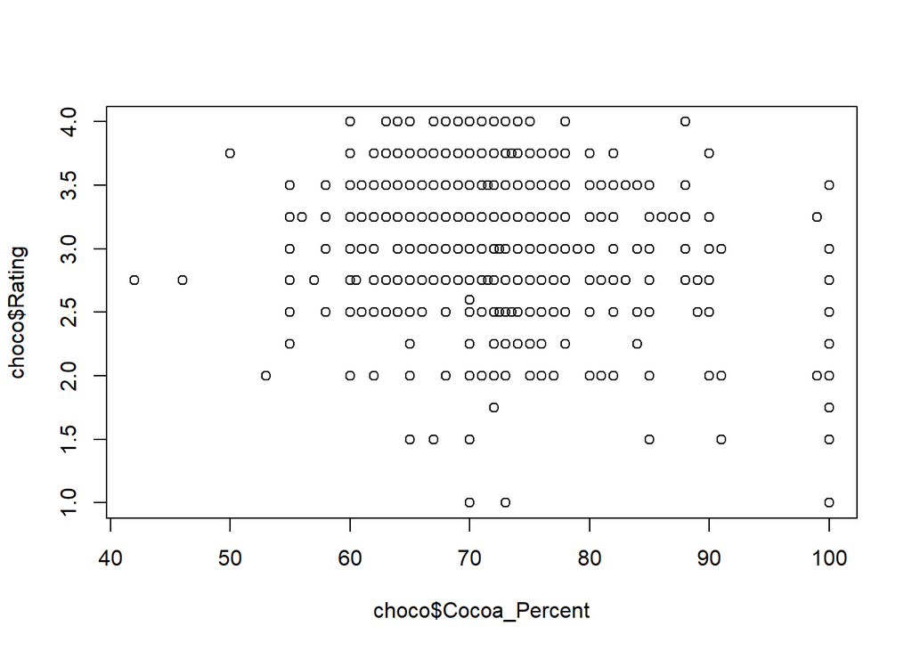

```r
plot(choco$Cocoa_Percent, choco$Rating)
```

```r
Ratings <- choco$Rating
CocoaPercentage <- choco$Cocoa_Percent
cor(Ratings, CocoaPercentage)
```

```
## [1] -0.1510178
```

3. I chose to create a scatter plot and find the correlation between Ratings and Cocoa Percentage. I argue that ratings do not depend on cocoa percentage, because there do not seem to be a consistent correlation between the two from looking at the correlation coefficient and scatter plot.

```r
summary(choco)
```

```
##       REF         Company            Location              Date
##  Min.   :   5   Length:2312        Length:2312        Min.   :2006
##  1st Qu.: 741   Class :character   Class :character   1st Qu.:2011
##  Median :1351   Mode  :character   Mode  :character   Median :2014
##  Mean   :1318                                         Mean   :2014
##  3rd Qu.:1912                                         3rd Qu.:2016
##  Max.   :2490                                         Max.   :2020
##  Bean_Origin        Specific_Bean_Origin Cocoa_Percent    Ingredients
##  Length:2312        Length:2312          Min.   : 42.00   Length:2312
##  Class :character   Class :character     1st Qu.: 70.00   Class :character
##  Mode  :character   Mode  :character     Median : 70.00   Mode  :character
##                                          Mean   : 71.65
##                                          3rd Qu.: 75.00
##                                          Max.   :100.00
##  Characteristics1   Characteristics2   Characteristics3   Characteristics4
##  Length:2312        Length:2312        Length:2312        Length:2312
##  Class :character   Class :character   Class :character   Class :character
##  Mode  :character   Mode  :character   Mode  :character   Mode  :character
##
##
##
##      Rating
##  Min.   :1.000
##  1st Qu.:3.000
##  Median :3.250
##  Mean   :3.184
##  3rd Qu.:3.500
##  Max.   :4.000
```

```r
#Sweet Characteristic
sweetChar <- subset(choco, select = c(Rating, Characteristics1, Characteristics2, Characteristics3, Characteristics4), subset =  Characteristics1=='sweet' | Characteristics2=='sweet' | Characteristics3=='sweet' | Characteristics4=='sweet')
summary(sweetChar$Rating)
```

```
##    Min. 1st Qu.  Median    Mean 3rd Qu.    Max.
##   2.000   2.750   3.000   3.046   3.250   4.000
```

```r
#Savory Characteristic
savoryChar <- subset(choco, select = c(Rating, Characteristics1, Characteristics2, Characteristics3, Characteristics4), subset =  Characteristics1=='savory' | Characteristics2=='savory' | Characteristics3=='savory' | Characteristics4=='savory')
summary(savoryChar$Rating)
```

```
##    Min. 1st Qu.  Median    Mean 3rd Qu.    Max.
##   2.750   3.000   3.250   3.212   3.500   3.750
```

```r
savoryChar
```

```
##      Rating Characteristics1 Characteristics2 Characteristics3 Characteristics4
## 2      3.50            cocoa          vegetal           savory             <NA>
## 50     2.75           roasty            sweet           savory             <NA>
## 88     3.25           smokey           savory             <NA>             <NA>
## 275    3.25           grassy           savory             sour             <NA>
## 912    3.75            cocoa           savory             <NA>             <NA>
## 923    3.75             oily           gritty           savory             <NA>
## 1416   3.00            nutty           cheese           savory             <NA>
## 1531   3.25             bold           savory           creamy             <NA>
## 1629   3.50           savory           smokey             <NA>             <NA>
## 1644   3.00       strawberry           savory             <NA>             <NA>
## 2111   3.00           earthy           savory            hammy             <NA>
## 2155   2.75             tart            sweet             sour           savory
## 2250   3.00       mild nutty            fruit           savory             <NA>
```

```r
#Creamy Characteristic
creamyChar <- subset(choco, select = c(Rating, Characteristics1, Characteristics2, Characteristics3, Characteristics4), subset =  Characteristics1=='creamy' | Characteristics2=='creamy' | Characteristics3=='creamy' | Characteristics4=='creamy')
summary(creamyChar$Rating)
```

```
##    Min. 1st Qu.  Median    Mean 3rd Qu.    Max.
##    1.50    3.25    3.50    3.48    3.75    4.00
```

```r
creamyChar
```

```
##      Rating Characteristics1   Characteristics2 Characteristics3
## 92     3.75           creamy              fruit            cocoa
## 96     3.00           creamy             earthy          vegetal
## 98     3.75           creamy          raspberry            nutty
## 104    4.00           creamy              sweet            cocoa
## 107    2.75           creamy          red berry           bitter
## 115    4.00           creamy             sticky    peanut butter
## 118    3.50           creamy               rich              rum
## 125    4.00           creamy            complex         balanced
## 137    4.00           creamy       bright fruit             <NA>
## 167    2.75           creamy        marshmallow              off
## 171    3.75           creamy              woody            cocoa
## 173    3.75           creamy               rich        blueberry
## 193    4.00           creamy            rounded           orange
## 199    3.50           creamy              sweet           fudgey
```

[output cut: 359 more lines]

```r
#Bold Characteristic
boldChar <- subset(choco, select = c(Rating, Characteristics1, Characteristics2, Characteristics3, Characteristics4), subset =  Characteristics1=='bold' | Characteristics2=='bold' | Characteristics3=='bold' | Characteristics4=='bold')
summary(boldChar$Rating)
```

```
##    Min. 1st Qu.  Median    Mean 3rd Qu.    Max.
##   2.000   3.250   3.500   3.324   3.500   3.750
```

```r
boldChar
```

```
##      Rating   Characteristics1 Characteristics2 Characteristics3
## 419    3.00              sandy             bold           cherry
## 499    3.50               bold       rich cocoa           coffee
## 532    3.75               bold            spice     hit of anise
## 555    3.50               bold           roasty           sticky
## 633    3.25               bold           floral              rum
## 760    3.00              sandy             bold           cherry
## 1139   3.25            complex             bold           gritty
## 1140   3.25               bold            spice       sour fruit
## 1451   2.00             smooth             bold           bitter
## 1531   3.25               bold           savory           creamy
## 1646   3.50             sticky             bold            nutty
## 1769   3.75               bold            nutty           floral
## 1899   3.50             gritty             bold     black pepper
## 1924   3.50          few grits             bold       dark berry
```

[output cut: 21 more lines]

```r
#All Results
summary(choco$Rating)
```

```
##    Min. 1st Qu.  Median    Mean 3rd Qu.    Max.
##   1.000   3.000   3.250   3.184   3.500   4.000
```

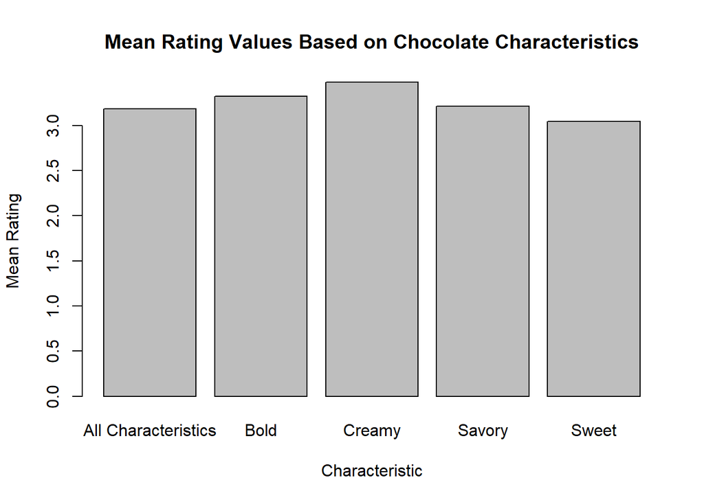

```r
#Barplot Comparing Ratings by Characteristics
charBarplotMeans <- c(mean(choco$Rating), mean(boldChar$Rating), mean(creamyChar$Rating), mean(savoryChar$Rating), mean(sweetChar$Rating))

barplot(charBarplotMeans,
main="Mean Rating Values Based on Chocolate Characteristics",
xlab="Characteristic",
ylab="Mean Rating",
names.arg = c("All Characteristics", "Bold", "Creamy", "Savory", "Sweet")
)
```

4. From comparing a few select characteristics, I found that chocolate described as being Sweet is more often rated worse than the average chocolate given a rating. In contrast, Creamy chocolate receives ratings higher than the average chocolate usually. Creamy chocolates received a mean of 3.48 on ratings and sweet received a mean rating of 3.046.

5a. For the first analysis, I would like to compare the rating results between the U.S.A. and France. For the second, I would like find out how ratings received by chocolates has changed throughout the years. For example, if chocolates review past 2016 receive lower rating more often than chocolates reviewed before 2010.

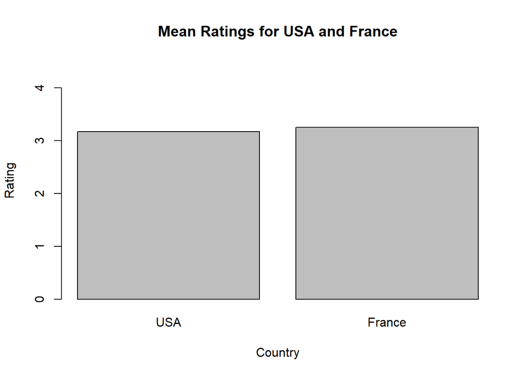

```r
#Barplot Mean Rating Comparison of USA and France
usaRatingVar <- subset(choco, select = c(Rating, Location), subset = Location=='U.S.A.')
franceRatingVar <- subset(choco, select = c(Rating, Location), subset = Location=='France')
twoNationRatingMeans <- c(mean(usaRatingVar$Rating),mean(franceRatingVar$Rating))
barplot(twoNationRatingMeans,
main="Mean Ratings for USA and France",
xlab="Country",
ylab="Rating",
names.arg=c("USA","France"),
ylim=c(0,4.5)
)
```

```r
#USA Rating Summary Statistics
summary(usaRatingVar)
```

```
##      Rating        Location
##  Min.   :1.500   Length:966
##  1st Qu.:3.000   Class :character
##  Median :3.250   Mode  :character
##  Mean   :3.171
##  3rd Qu.:3.500
##  Max.   :4.000
```

```r
sd(usaRatingVar$Rating)
```

```
## [1] 0.43424
```

```r
#France Rating Summary Statistics
summary(franceRatingVar)
```

```
##      Rating       Location
##  Min.   :1.50   Length:175
##  1st Qu.:3.00   Class :character
##  Median :3.25   Mode  :character
##  Mean   :3.25
##  3rd Qu.:3.50
##  Max.   :4.00
```

```r
sd(franceRatingVar$Rating)
```

```
## [1] 0.512768
```

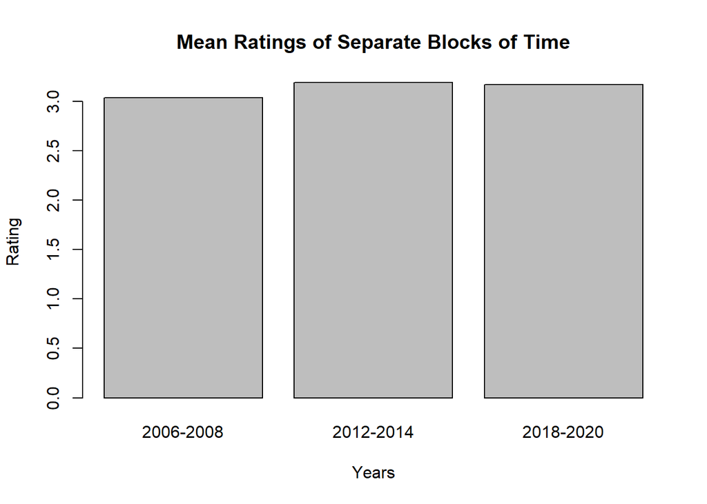

```r
#Barplot of Year Chunks versus Rating
earliestThreeYears <- subset(choco, select=c(Rating,Date), subset= Date==2006 | Date==2007 | Date==2008)
middleThreeYears <- subset(choco, select=c(Rating,Date), subset= Date==2012 | Date==2013 | Date==2014)
latestThreeYears <- subset(choco, select=c(Rating,Date), subset= Date==2018 | Date==2019 | Date==2020)
threeTimeRatingMeans <- c(mean(earliestThreeYears$Rating), mean(middleThreeYears$Rating), mean(latestThreeYears$Rating))

barplot(threeTimeRatingMeans,
main="Mean Ratings of Separate Blocks of Time",
xlab="Years",
ylab="Rating",
names.arg=c("2006-2008","2012-2014","2018-2020")

)
```

```r
#Earliest Ratings Summaries
summary(earliestThreeYears$Rating)
```

```
##    Min. 1st Qu.  Median    Mean 3rd Qu.    Max.
##   1.000   2.750   3.000   3.034   3.500   4.000
```

```r
sd(earliestThreeYears$Rating)
```

```
## [1] 0.6334095
```

```r
#Middle Ratings Summaries
summary(middleThreeYears$Rating)
```

```
##    Min. 1st Qu.  Median    Mean 3rd Qu.    Max.
##   1.500   2.750   3.250   3.189   3.500   4.000
```

```r
sd(middleThreeYears$Rating)
```

```
## [1] 0.4457269
```

```r
#Latest Ratings Summaries
summary(latestThreeYears$Rating)
```

```
##    Min. 1st Qu.  Median    Mean 3rd Qu.    Max.
##   2.000   3.000   3.125   3.165   3.500   4.000
```

```r
sd(latestThreeYears$Rating)
```

```
## [1] 0.3755335
```

5b. (USA and France Comparison of Ratings) There seems to be some small differences in ratings between the two countries, USA and France. The USA has a mean of 3.171 versus France’s mean of 3.25. This does lead me to believe that a chocolate from France will more likely be of a higher rating and possibly even quality when compared to a USA chocolate. I should note that the standard deviation for the USA is small than France’s. From the standard deviations, I believe that USA chocolates may receive lower scores on average when compared to France chocolates. However, USA chocolates vary less in Ratings and so receive more consistent ratings than France chocolates.

5c. (Comparison of Ratings between oldest and newest reviews) I found that the mean ratings during 2012-2014 and 2018-2020 are close, whereas the mean rating for 2006-2008 was considerably lower. 2006-2008 mean rating being 3.034 compared to 2018-2020 being 3.165. It is notable that the standard deviation of ratings decrease as time passed. The 2006-2008 standard deviation is 0.63 and the 2018-2020 standard deviation is 0.38. It seemed that as the reviews have been complete, they have progressively come to more similar conclusions on ratings.